# HHTS: transit ridership (2017, 2019, 2021) Analysis

Mary Richards

July 11, 2022

# Introduction

The work presented in this document contains analysis of commute mode, with a focus on transit ridership, in relation to auto ownership and geography. The analysis includes 2021 data and utilizes PSRC’s R package, [psrc.travelsurvey](https://psrc.github.io/psrc.travelsurvey/index.html).

- **Has commuting by transit changed with COVID-19?** (2017 and 2019 vs. 2021)
  - Who uses transit? Have there been shifts over time?
- **How does vehicle ownership influence transit commuting use over time?**

*Filtering out children and those who do not commute*

# Descriptive Stats: 2017

## Transit

Using ‘commute_mode’ defined as: ‘Usual way of commuting to current location/office’  
*survey logic*: if workplace = fixed/varied/telework some days

Workplace options:

- **Only one work location outside of home**
- Work at home ONLY (telework, self-employed)
- **Telework some days and travel to a work location some days**
- **Work location regularly varies (different offices/jobsites)**
- Drive/travel for work (driver, sales)

```
## Frequencies
## df$commute_mode
## Type: Character
##
##                                                                                         Freq   % Valid   % Valid Cum.   % Total   % Total Cum.
## ------------------------------------------------------------------------------------- ------ --------- -------------- --------- --------------
##                                                                Airplane or helicopter      8     0.231          0.231     0.128          0.128
##                                                                     Bicycle or e-bike    156     4.496          4.726     2.504          2.633
##                                                                  Bus (public transit)    842    24.265         28.991    13.517         16.150
##                                             Carpool ONLY with other household members    187     5.389         34.380     3.002         19.152
##       Carpool with other people not in household (may also include household members)     70     2.017         36.398     1.124         20.276
##                                                       Commuter rail (Sounder, Amtrak)     13     0.375         36.772     0.209         20.485
##                                                                           Drive alone   1728    49.798         86.571    27.741         48.226
##                                                                   Ferry or water taxi      6     0.173         86.744     0.096         48.322
##                                                              Motorcycle/moped/scooter     12     0.346         87.089     0.193         48.515
##                                                               Other (e.g. skateboard)      2     0.058         87.147     0.032         48.547
##                 Other hired service (Uber, Lyft, or other smartphone-app car service)     10     0.288         87.435     0.161         48.708
##                                                                           Paratransit      1     0.029         87.464     0.016         48.724
##                                                                Private bus or shuttle     22     0.634         88.098     0.353         49.077
##                                                                             Streetcar      3     0.086         88.184     0.048         49.125
##                                                               Taxi (e.g., Yellow Cab)      1     0.029         88.213     0.016         49.141
##                                                Urban rail (Link light rail, monorail)     95     2.738         90.951     1.525         50.666
##                                                                               Vanpool     28     0.807         91.758     0.450         51.116
##                                                              Walk, jog, or wheelchair    286     8.242        100.000     4.591         55.707
##                                                                                  <NA>   2759                             44.293        100.000
##                                                                                 Total   6229   100.000        100.000   100.000        100.000
```

The NAs represent those who only work at home and those who drive for their jobs.

When the commute modes are simplified:

```
## Frequencies
## df_simp_2$commute_mode
## Type: Factor
##
##                                Freq   % Valid   % Valid Cum.   % Total   % Total Cum.
## ---------------------------- ------ --------- -------------- --------- --------------
##       1-Active/micro-transit    454     13.08          13.08     13.08          13.08
##             2-Public Transit    960     27.67          40.75     27.67          40.75
##                3-Drive alone   1728     49.80          90.55     49.80          90.55
##                4-Other modes    328      9.45         100.00      9.45         100.00
##                         <NA>      0                               0.00         100.00
##                        Total   3470    100.00         100.00    100.00         100.00
```

*do we count hired services/taxis as SOV?* it’s currently categorized as ‘other modes’

### Race - POC/Non-POC

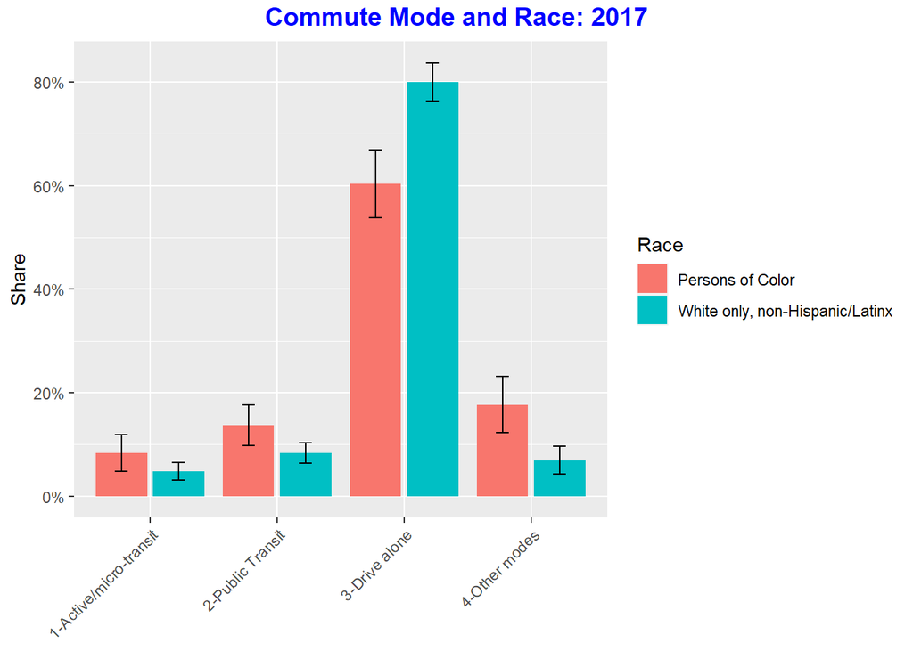

#### Focusing on Active/Public Transit

To look at numbers more closely

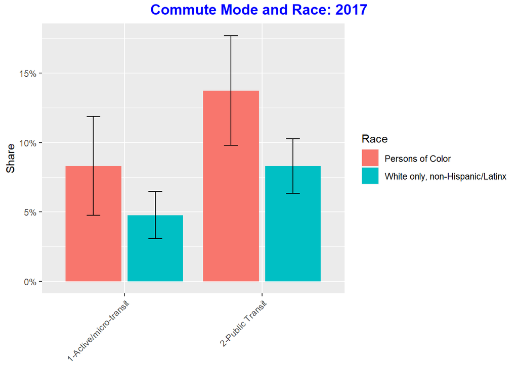

### Race - Asian POC/Non-Asian POC/White

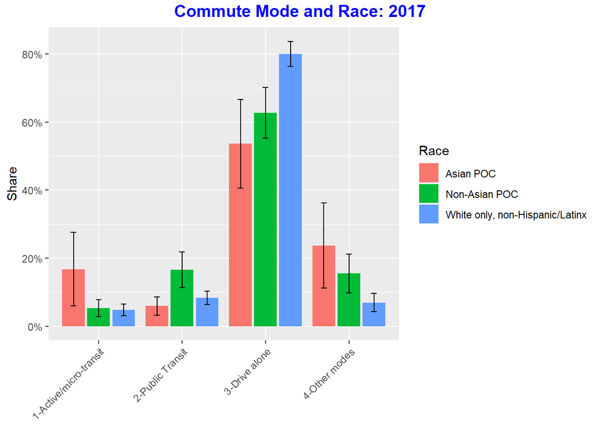

### Income

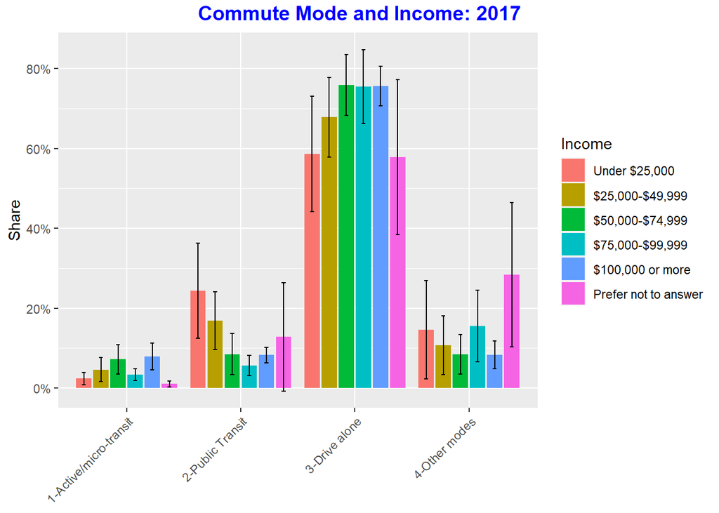

#### Focusing on Active/Public Transit

To look at numbers more closely

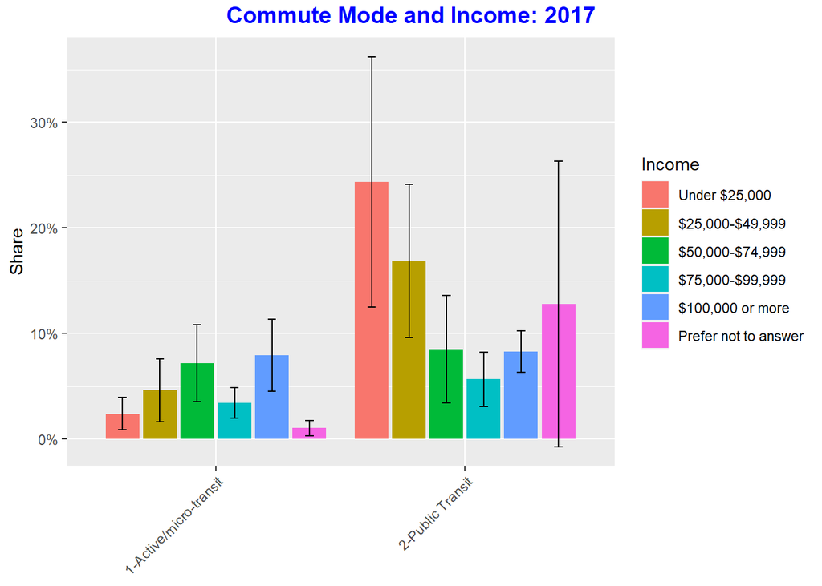

### Education

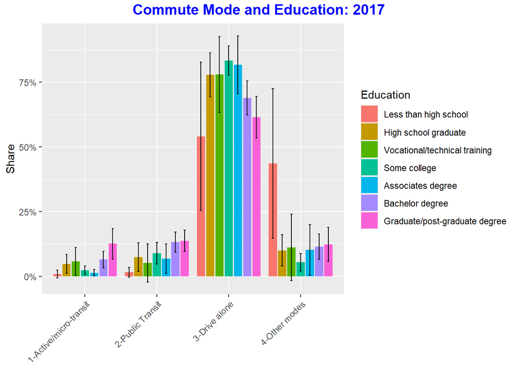

#### Focusing on Active/Public Transit

To look at numbers more closely

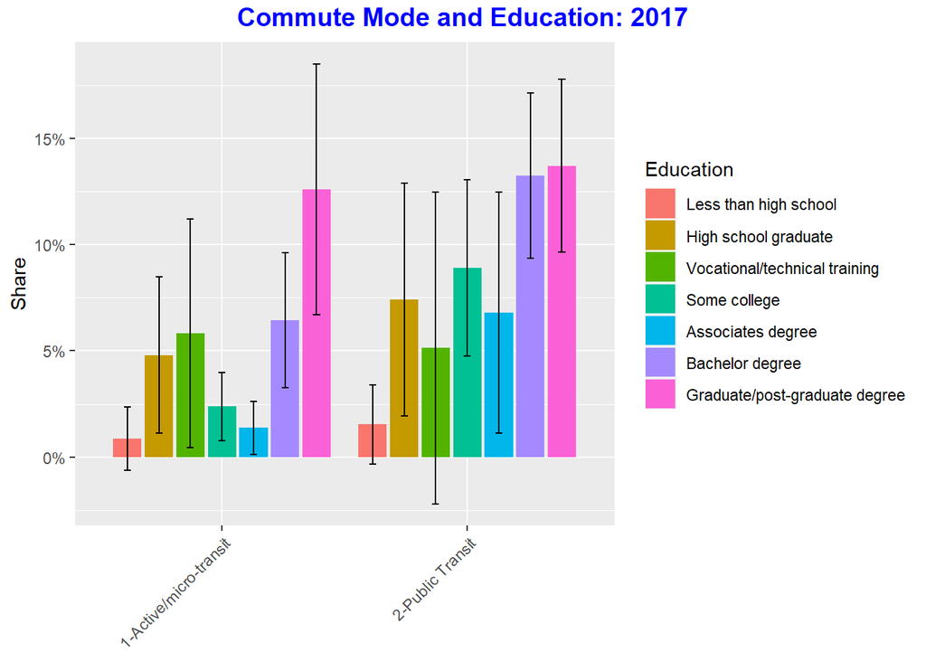

### Regional Growth Center - home location

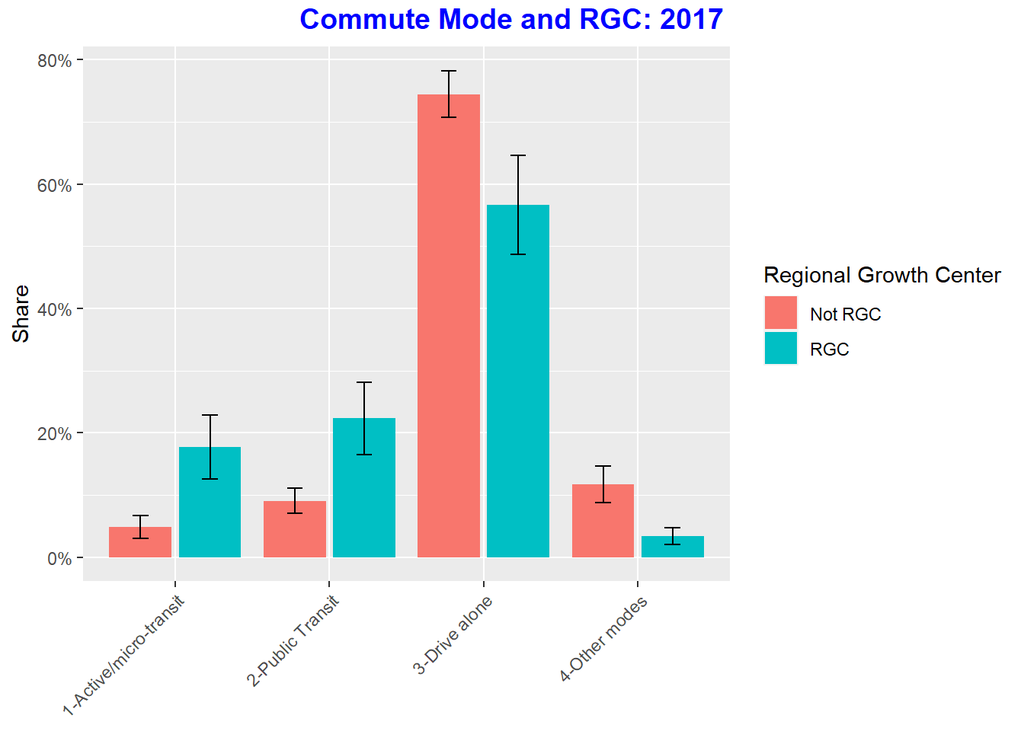

#### Focusing on Active/Public Transit

To look at numbers more closely

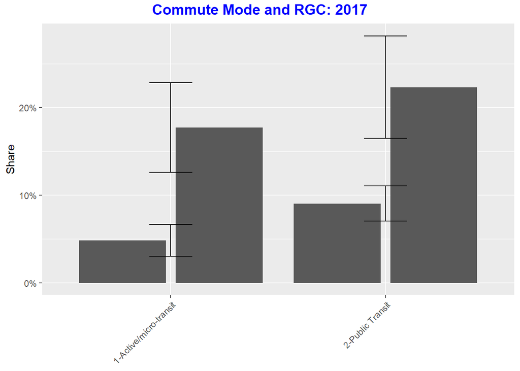

### No-vehicle households

survey logic: vehicle_count==“0 (no vehicles)”

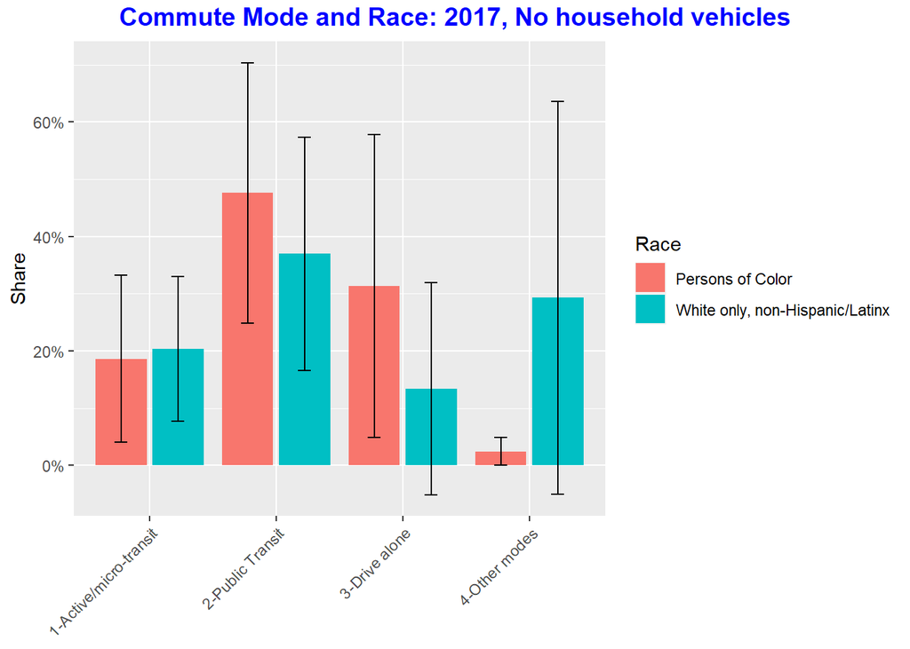

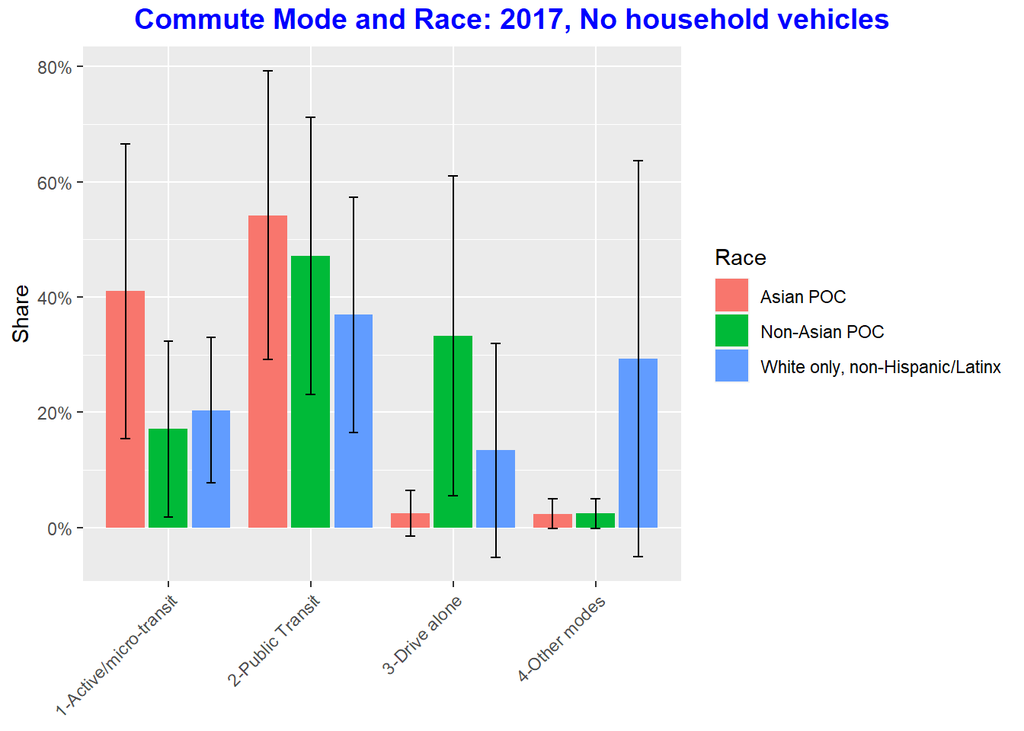

#### Demographics of no-vehicle households

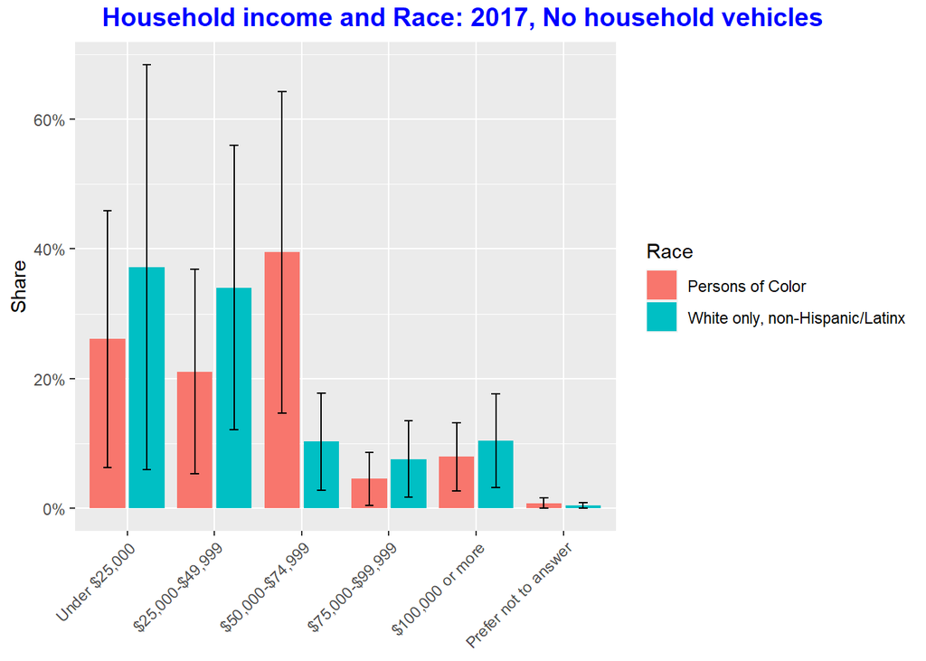

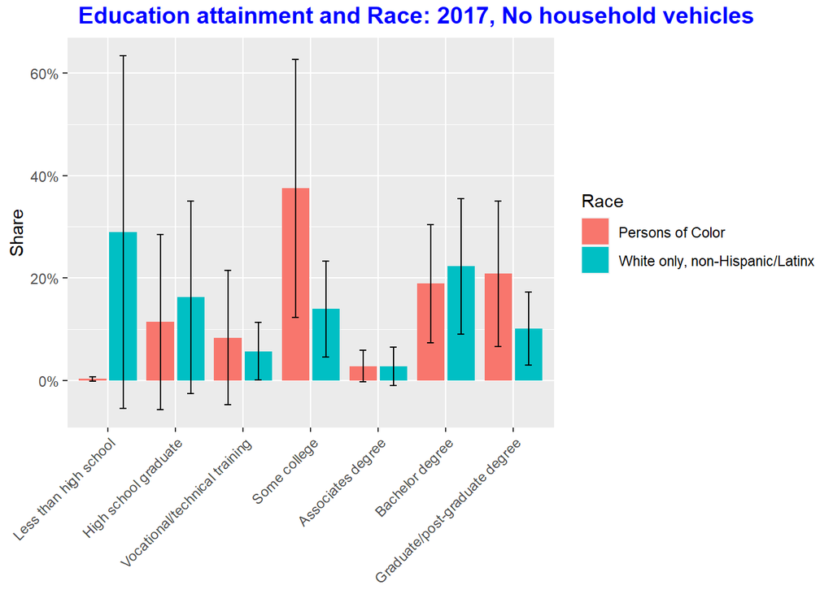

# Descriptive Stats: 2017, 2019, 2017-2019, 2021

## Race (2 categories) and transit mode

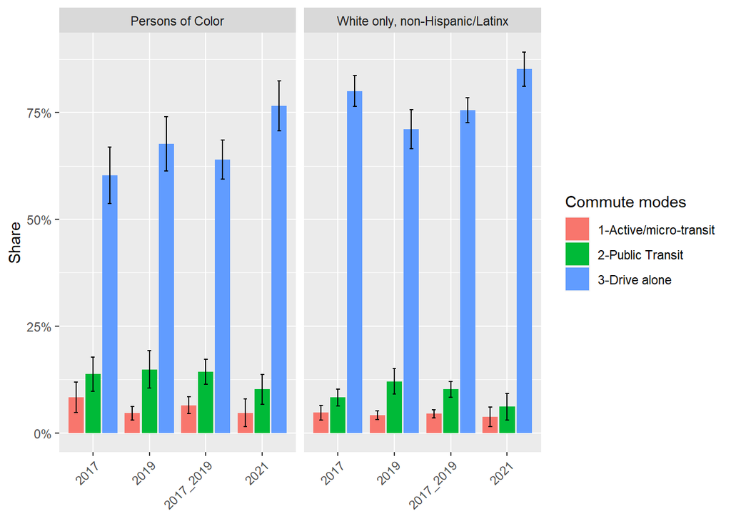

## Race (3 categories) and transit mode

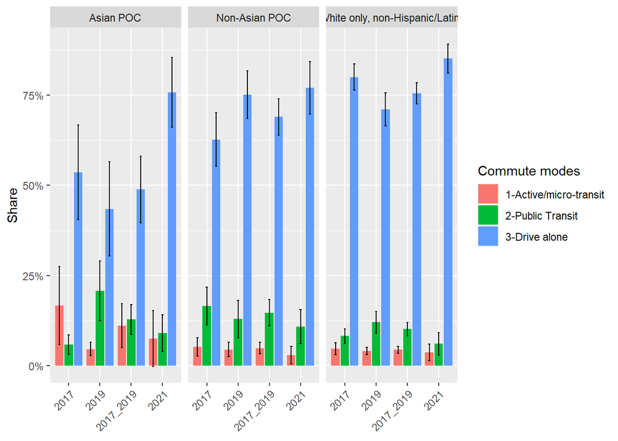

# Vehicle Ownership

## Different ways to quantify vehicle ownership

1. **hhsize/vehicle_count** = Household size
2. **numadults/vehicle_count** = Number of adults (18+)
3. **numworkers/vehicle_count** = Number of workers (number of household members with 1+ jobs)

Because we’re interested in commute modes, we will be focusing on the number of workers within a household

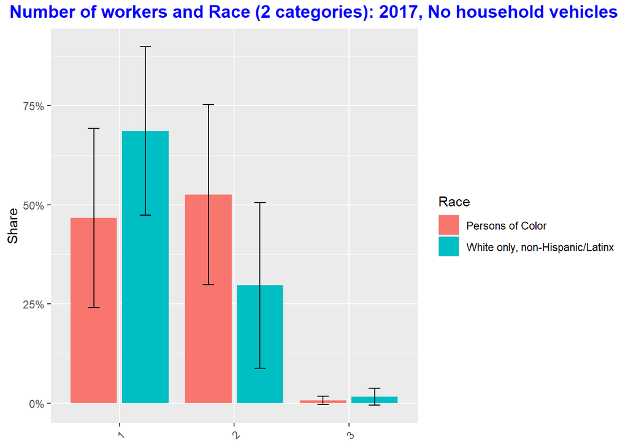

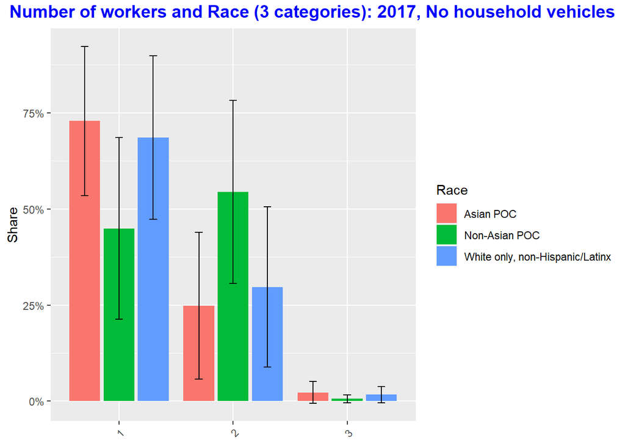

The larger the number, the more people per vehicle in each household. Numbers less than 1 represent households with more vehicles than people. People in households without a vehicle are excluded from this analysis.

#### 3. Number of workers

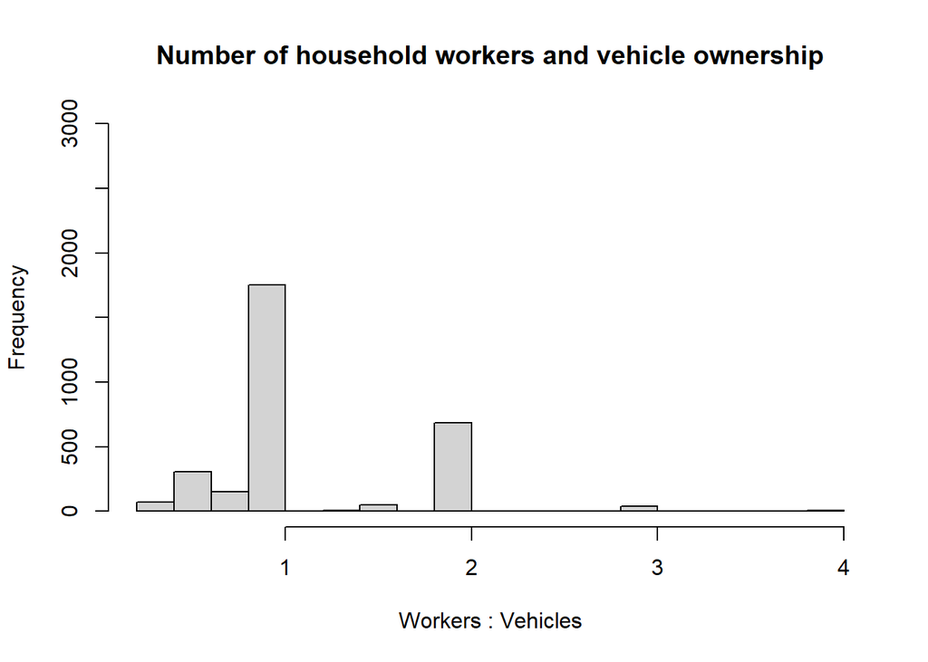

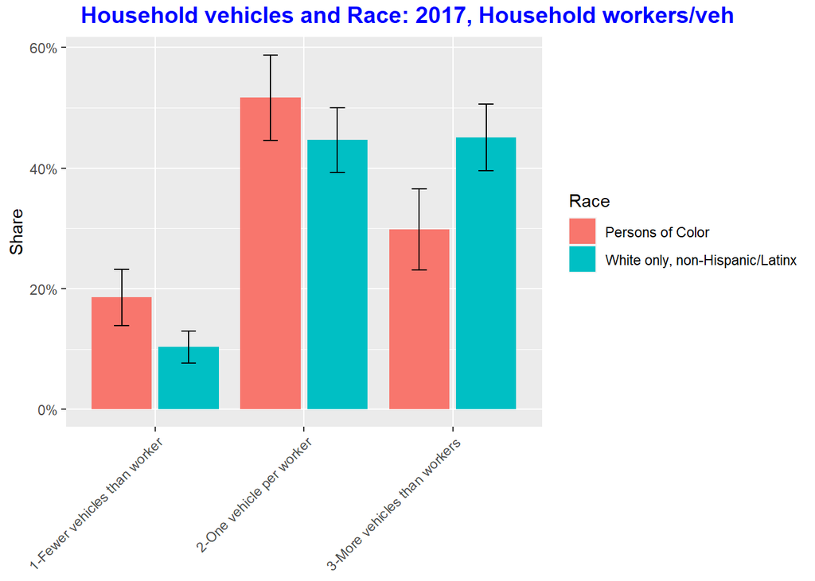

# Analysis

## Transit and Household Auto Ownership

#### By Race

##### Simplified Vehicle Numbers

Back to top of the page